# Curso_12_Correlation

```r
# https://github.com/tidyverse/ggplot2/wiki/Flying-over-the-usa

library(ggplot2)
library(dplyr)
library(nycflights13) # for data

names(flights)
head(flights)
```

1. 'year'

2. 'month'

3. 'day'

4. 'dep_time'

5. 'sched_dep_time'

6. 'dep_delay'

7. 'arr_time'

8. 'sched_arr_time'

9. 'arr_delay'

10. 'carrier'

11. 'flight'

12. 'tailnum'

13. 'origin'

14. 'dest'

15. 'air_time'

16. 'distance'

17. 'hour'

18. 'minute'

19. 'time_hour'

| year | month | day | dep_time | sched_dep_time | dep_delay | arr_time | sched_arr_time | arr_delay | carrier | flight | tailnum | origin | dest | air_time | distance | hour | minute | time_hour |
| --- | --- | --- | --- | --- | --- | --- | --- | --- | --- | --- | --- | --- | --- | --- | --- | --- | --- | --- |
| 2013 | 1 | 1 | 517 | 515 | 2 | 830 | 819 | 11 | UA | 1545 | N14228 | EWR | IAH | 227 | 1400 | 5 | 15 | 2013-01-01 05:00:00 |
| 2013 | 1 | 1 | 533 | 529 | 4 | 850 | 830 | 20 | UA | 1714 | N24211 | LGA | IAH | 227 | 1416 | 5 | 29 | 2013-01-01 05:00:00 |
| 2013 | 1 | 1 | 542 | 540 | 2 | 923 | 850 | 33 | AA | 1141 | N619AA | JFK | MIA | 160 | 1089 | 5 | 40 | 2013-01-01 05:00:00 |
| 2013 | 1 | 1 | 544 | 545 | -1 | 1004 | 1022 | -18 | B6 | 725 | N804JB | JFK | BQN | 183 | 1576 | 5 | 45 | 2013-01-01 05:00:00 |
| 2013 | 1 | 1 | 554 | 600 | -6 | 812 | 837 | -25 | DL | 461 | N668DN | LGA | ATL | 116 | 762 | 6 | 0 | 2013-01-01 06:00:00 |
| 2013 | 1 | 1 | 554 | 558 | -4 | 740 | 728 | 12 | UA | 1696 | N39463 | EWR | ORD | 150 | 719 | 5 | 58 | 2013-01-01 05:00:00 |

```r
mD <- mean(flights$dep_delay, na.rm = TRUE)
sdD <- sd(flights$dep_delay, na.rm = TRUE)

mD
sdD
```

12.6390702573047

40.21006089213

```r
flights_simple <- flights %>% select(dep_delay) %>% mutate(z = (dep_delay - mD)/sdD)

head(flights_simple)
head(arrange(flights_simple, desc(z)))
```

| dep_delay | z |
| --- | --- |
| 2 | -0.2645873 |
| 4 | -0.2148485 |
| 2 | -0.2645873 |
| -1 | -0.3391955 |
| -6 | -0.4635425 |
| -4 | -0.4138037 |

| dep_delay | z |
| --- | --- |
| 1301 | 32.04076 |
| 1137 | 27.96218 |
| 1126 | 27.68862 |
| 1014 | 24.90324 |
| 1005 | 24.67942 |
| 960 | 23.56030 |

```r
# 32 es mucho! Se acuerdan que z está entre -5 y 5.
# cuântos están a 2 sds del promedio?

flights_simple %>% filter(z <= 2)
```

| dep_delay | z |
| --- | --- |
| 2 | -0.26458727 |
| 4 | -0.21484847 |
| 2 | -0.26458727 |
| -1 | -0.33919546 |
| -6 | -0.46354245 |
| -4 | -0.41380366 |
| -5 | -0.43867306 |
| -3 | -0.38893426 |
| -3 | -0.38893426 |
| -2 | -0.36406486 |
| -2 | -0.36406486 |
| -2 | -0.36406486 |
| -2 | -0.36406486 |
| -2 | -0.36406486 |
| -1 | -0.33919546 |
| 0 | -0.31432607 |
| -1 | -0.33919546 |
| 0 | -0.31432607 |
| 0 | -0.31432607 |
| 1 | -0.28945667 |
| -8 | -0.51328125 |
| -3 | -0.38893426 |
| -4 | -0.41380366 |
| -4 | -0.41380366 |
| 0 | -0.31432607 |
| 8 | -0.11537088 |
| 11 | -0.04076269 |
| 3 | -0.23971787 |
| 0 | -0.31432607 |
| 0 | -0.31432607 |
| ... | ... |
| 15 | 0.058714901 |
| 49 | 0.904274426 |
| 5 | -0.189979077 |
| -8 | -0.513281249 |
| 74 | 1.526009371 |
| -1 | -0.339195464 |
| 21 | 0.207931288 |
| -5 | -0.438673055 |
| -2 | -0.364064862 |
| -2 | -0.364064862 |
| -2 | -0.364064862 |
| 30 | 0.431755868 |
| -9 | -0.538150646 |
| 0 | -0.314326066 |
| 13 | 0.008976105 |
| 0 | -0.314326066 |
| 10 | -0.065632088 |
| -7 | -0.488411851 |
| -9 | -0.538150646 |
| -2 | -0.364064862 |
| 27 | 0.357147675 |
| 72 | 1.476270576 |
| -14 | -0.662497635 |
| 80 | 1.675225758 |
| -8 | -0.513281249 |
| -5 | -0.438673055 |
| -10 | -0.563020044 |
| -5 | -0.438673055 |
| 12 | -0.015893292 |
| -10 | -0.563020044 |

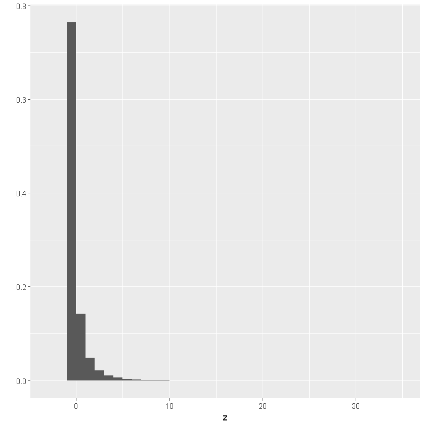

```r
ggplot(flights_simple) + geom_histogram(aes(z,  y=..count../sum(..count..)), breaks = seq(-3, 35)) + ylab("")
```

```r
mD <- mean(flights$arr_delay, na.rm = T)
sdD <- sd(flights$arr_delay, na.rm = T)

mD
sdD
```

6.89537675731489

44.633291690194

```r
flights_simple <- flights %>% select(arr_delay) %>%
                            mutate(z = (arr_delay - mD)/sdD)

flights_simple %>% arrange(desc(z))
```

| arr_delay | z |
| --- | --- |
| 1272 | 28.34442 |
| 1127 | 25.09572 |
| 1109 | 24.69243 |
| 1007 | 22.40714 |
| 989 | 22.00386 |
| 931 | 20.70438 |
| 915 | 20.34590 |
| 895 | 19.89781 |
| 878 | 19.51693 |
| 875 | 19.44971 |
| 856 | 19.02402 |
| 852 | 18.93440 |
| 851 | 18.91200 |
| 850 | 18.88959 |
| 847 | 18.82238 |
| 846 | 18.79997 |
| 834 | 18.53111 |
| 821 | 18.23985 |
| 802 | 17.81416 |
| 796 | 17.67973 |
| 784 | 17.41087 |
| 783 | 17.38847 |
| 783 | 17.38847 |
| 780 | 17.32125 |
| 773 | 17.16442 |
| 769 | 17.07480 |
| 767 | 17.02999 |
| 744 | 16.51468 |
| 744 | 16.51468 |
| 688 | 15.26001 |
| ... | ... |
| NA | NA |
| NA | NA |
| NA | NA |
| NA | NA |
| NA | NA |
| NA | NA |
| NA | NA |
| NA | NA |
| NA | NA |
| NA | NA |
| NA | NA |
| NA | NA |
| NA | NA |
| NA | NA |
| NA | NA |
| NA | NA |
| NA | NA |
| NA | NA |
| NA | NA |
| NA | NA |
| NA | NA |
| NA | NA |
| NA | NA |
| NA | NA |
| NA | NA |
| NA | NA |
| NA | NA |
| NA | NA |
| NA | NA |
| NA | NA |

1. 336776

2. 2

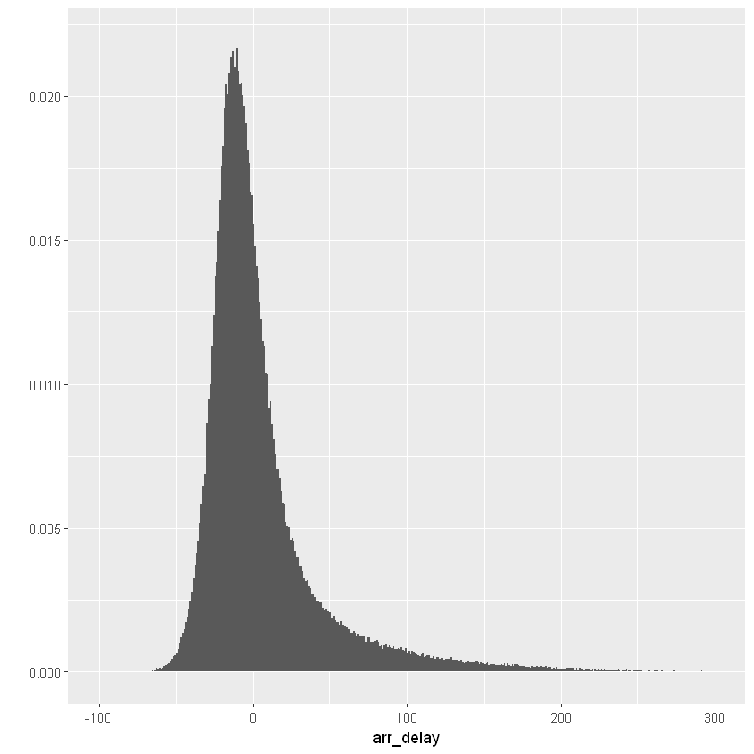

```r
ggplot(flights_simple) + geom_histogram(aes(arr_delay,  y=..count../sum(..count..)),
                                        breaks = seq(-100, 300)) + ylab("")

dim(flights_simple)
```

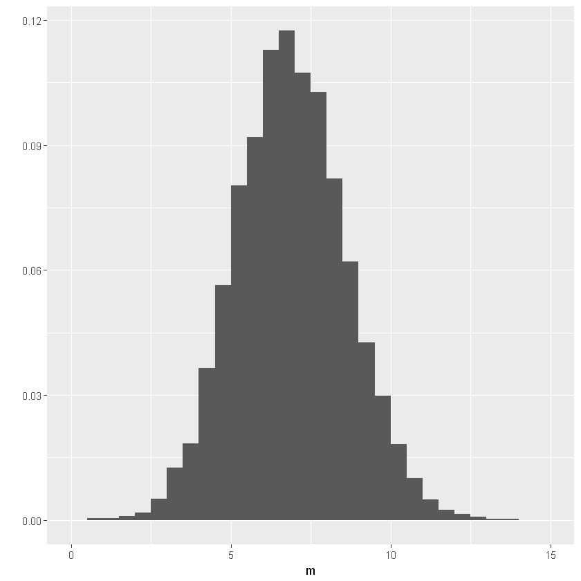

```r
sample_size = 700
m <- vector()

for(i in 1:10000){
    m[i] <- mean(sample_n(tbl = flights_simple, size = sample_size, replace = T)$arr_delay, na.rm = T)
}

m <- data.frame(m = m)

ggplot(m) + geom_histogram(aes(m, y=..count../sum(..count..)), breaks=seq(0, 15, by=0.5)) + ylab("")
```

# El Teorema central límite (CLT)

Para una muestra suficientemente grande tomada al azar y con o sin reemplazo tenemos que:

```
la distribución del promdio de las muestras es normal(se ve como una campana).
```

Tiene una ecuación (sim alrededor de 0).

\begin{equation}\Huge \phi(z) := \frac{1}{\sqrt{2\pi}} e^{-\frac{z^2}{2}}, \quad -\infty < z < \infty. \end{equation}

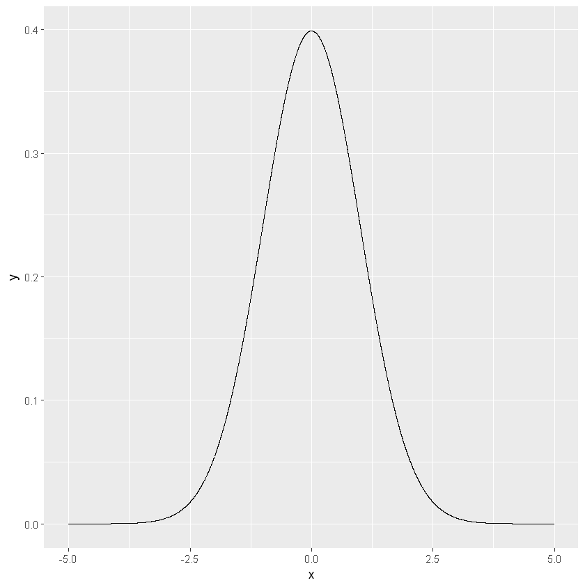

```r
normal_cdf <- function(mean, sd, pt){
    x <- seq(-5, 5, by = 0.001)
    y <- dnorm(x, mean = mean, sd = sd, log = FALSE)

    xy <- data.frame(x=x, y=y)

    return(ggplot(xy) + geom_line(aes(x=x, y=y)))
}

 normal_cdf(0, 1, T)
```

Para encontrar la proporción de puntos que están entre dos valors calculamos la integral (aprox cuando no se puede calcualr). El área debajo de $\phi(z)$ es 1.

0.977249868051821

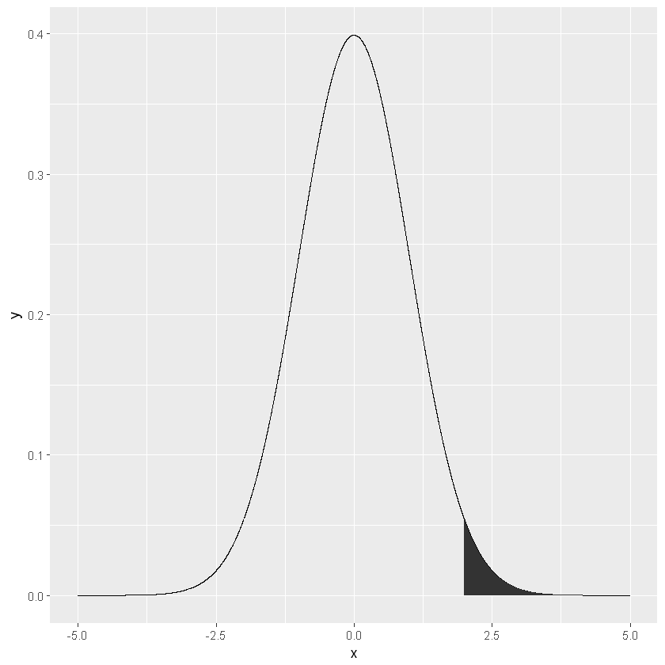

```r
CDF <- function(mean, sd, p){
    x <- seq(-5, 5, by = 0.001)
    y <- dnorm(x, mean = mean, sd = sd, log = FALSE)

    xy <- data.frame(x=x, y=y)
    ytop<-dnorm(x = p, mean = mean, sd = sd)

    #First subst the data and add the coordinates to make it shade to y = 0
    shade <- rbind(c(p,0), subset(xy, x > p), c(xy[nrow(xy), "X"], 0))

    #Then use this new data.frame with geom_polygon
    # http://stackoverflow.com/questions/10659133/local-variables-within-aes
    .e <- environment()
    ggplot(xy, enviroment = .e) + geom_line(aes(x=x, y=y)) +
        geom_segment(aes(x = p, y = 0, xend = p, yend = ytop)) + geom_polygon(data = shade, aes(x, y)) #+ coord_fixed(ratio = 1)
}

pnorm(q = 2, mean = 0, sd = 1)
CDF(mean = 0, sd = 1, p = 2)
```

Qué proporción representa la parte sombreada?

Cómo calcular el área entre -1 y 1?

# Relaciones entre dos variables

Tipos de associación

```
Tendencia: Si una vaiable aumenta la otra también.

Patrones: Hay una forma en la realción.
```

Para hacer esto primero hacemos un dibujo!

```r
carros = read.table(file = "C:/Users/Personal/Data-Science-Students/Tables/imports-85.data",
                    sep = ',', header = T)
head(carros)
names(carros)
```

| symboling | normalized.losses | make | fuel.type | aspiration | num.of.doors | body.style | drive.wheels | engine.location | wheel.base | ... | num.of.cylinders | engine.size | fuel.syste | stroke | compression.ratio | horsepower | peak.rpm | city.mpg | highway.mpg | price |
| --- | --- | --- | --- | --- | --- | --- | --- | --- | --- | --- | --- | --- | --- | --- | --- | --- | --- | --- | --- | --- |
| 3 | NA | alfa-romero | gas | std | two | convertible | rwd | front | 88.6 | ... | 130 | mpfi | 3.47 | 2.68 | 9.0 | 111 | 5000 | 21 | 27 | 13495 |
| 3 | NA | alfa-romero | gas | std | two | convertible | rwd | front | 88.6 | ... | 130 | mpfi | 3.47 | 2.68 | 9.0 | 111 | 5000 | 21 | 27 | 16500 |
| 1 | NA | alfa-romero | gas | std | two | hatchback | rwd | front | 94.5 | ... | 152 | mpfi | 2.68 | 3.47 | 9.0 | 154 | 5000 | 19 | 26 | 16500 |
| 2 | 164 | audi | gas | std | four | sedan | fwd | front | 99.8 | ... | 109 | mpfi | 3.19 | 3.40 | 10.0 | 102 | 5500 | 24 | 30 | 13950 |
| 2 | 164 | audi | gas | std | four | sedan | 4wd | front | 99.4 | ... | 136 | mpfi | 3.19 | 3.40 | 8.0 | 115 | 5500 | 18 | 22 | 17450 |
| 2 | NA | audi | gas | std | two | sedan | fwd | front | 99.8 | ... | 136 | mpfi | 3.19 | 3.40 | 8.5 | 110 | 5500 | 19 | 25 | 15250 |

1. 'symboling'

2. 'normalized.losses'

3. 'make'

4. 'fuel.type'

5. 'aspiration'

6. 'num.of.doors'

7. 'body.style'

8. 'drive.wheels'

9. 'engine.location'

10. 'wheel.base'

11. 'length'

12. 'width'

13. 'height'

14. 'curb.weight'

15. 'borrom'

16. 'engine.type'

17. 'num.of.cylinders'

18. 'engine.size'

19. 'fuel.syste'

20. 'stroke'

21. 'compression.ratio'

22. 'horsepower'

23. 'peak.rpm'

24. 'city.mpg'

25. 'highway.mpg'

26. 'price'

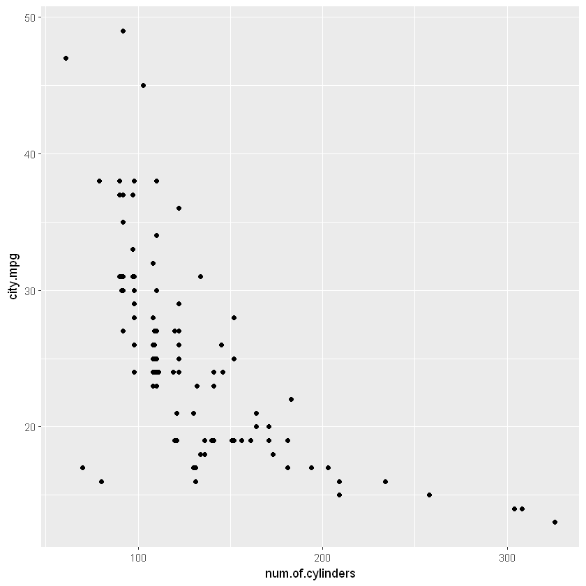

```r
ggplot(carros, aes(x=num.of.cylinders, y=city.mpg)) + geom_point()
```

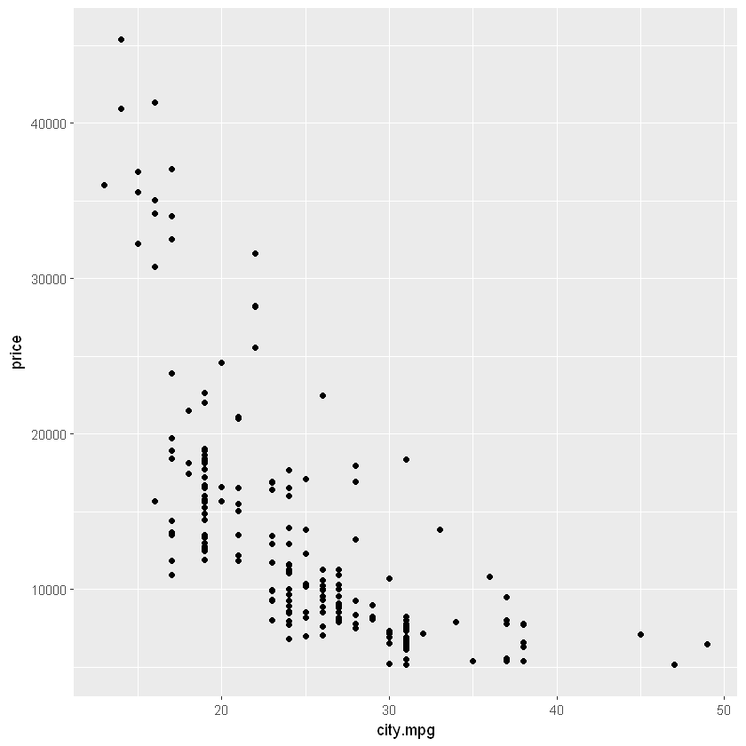

```r
ggplot(carros, aes(x=city.mpg, y=price)) + geom_point()
```

# Correlación

Mide si la asociación es lineal.

Está en unidades estandar.

r está entre -1 y 1.

```
*r = 1 una línea  para arriba (45 grados)
*r = 0 sin correlación.
```

http://guessthecorrelation.com/

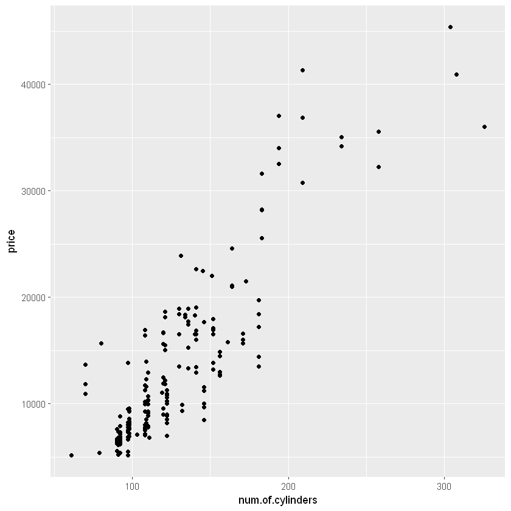

```r
ggplot(carros, aes(x=num.of.cylinders, y=price)) + geom_point()
```

Multiplicar unidades estándar y tomar el promedio.

```
    Unidades estándar sirven para comparar diferentes dimensiones(2 sd's del promedio).
    Multiplicación tiene el buen signo.
    No importa el orden: corr(x,y) = corr(y,x)
```

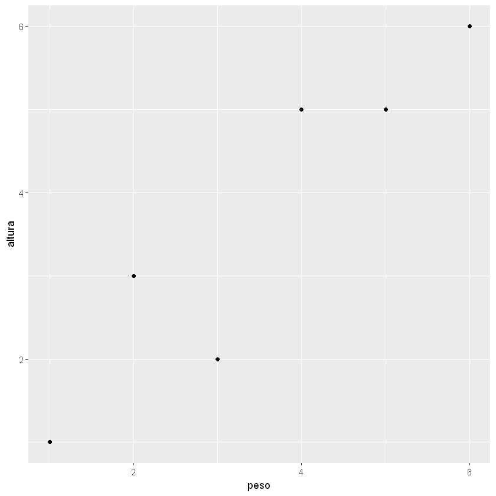

```r
df <- data.frame(peso = c(1, 2, 3, 4, 5, 6), altura = c(1, 3, 2, 5, 5, 6))

ggplot(df, aes(peso, altura)) + geom_point()
```

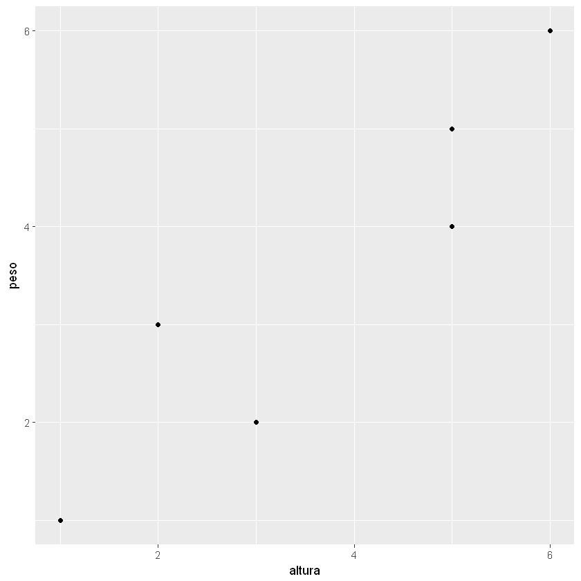

```r
ggplot(df) + geom_point(aes(altura, peso)) # La gente mas alta es también la mas pesda y vice-versa.
```

# Correlación no es causalidad

Hay una correlación positiva entre el peso y leer bien. Leer mas te hace mas pesado? O ser mas pesado hace que leeas mejor?

Qué pasa con la edad?

Qué hay que hacer para establecer causalidad? Inferencia en un experimento aleatorio.

Siempre hagan un dibujo primero.

0

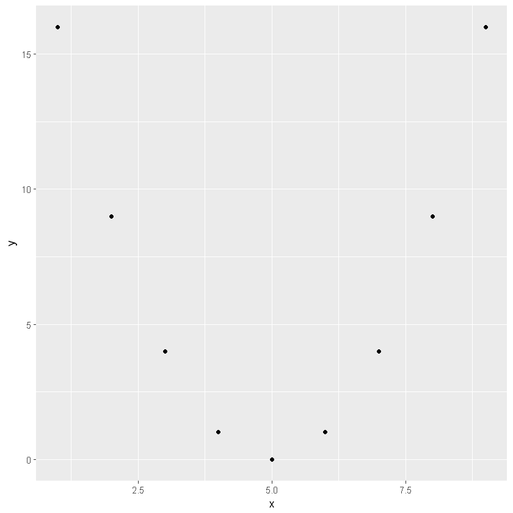

```r
x <- 1:9
y <- (x-5)^2
df <- data.frame(x = x, y = y)

ggplot(df) + geom_point(aes(x, y))

cor(x, y) # pero hay una relacón! No hay una relación lineal.
```

0

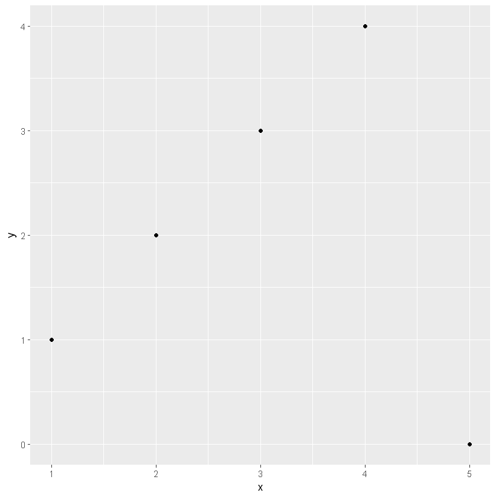

```r
x <- 1:5
y <- c(1, 2, 3, 4, 0)
df <- data.frame(x = x, y = y)

ggplot(df) + geom_point(aes(x, y))

cor(x, y) # un punto puede afectar la correlación. Usen todos los puntos! Investiguen porque son así.
```

```r
# http://blog.prepscholar.com/average-sat-scores-by-state-most-recent
SAT = read.table(file = "C:/Users/Personal/Data-Science-Students/Tables/sat.csv",
                    sep = "\t", header = T)
head(SAT)
names(SAT)
```

| State | Participation | Reading | Math | Writing | Total | New.SAT |
| --- | --- | --- | --- | --- | --- | --- |
| Alabama | 6 | 557 | 551 | 543 | 1651 | 1190 |
| Alaska | 52 | 485 | 479 | 460 | 1424 | 1040 |
| Arizona | 34 | 528 | 532 | 505 | 1565 | 1140 |
| Arkansas | 4 | 570 | 569 | 553 | 1692 | 1210 |
| California | 60 | 491 | 500 | 485 | 1476 | 1080 |
| Colorado | 12 | 587 | 589 | 571 | 1747 | 1250 |

1. 'State'

2. 'Participation'

3. 'Reading'

4. 'Math'

5. 'Writing'

6. 'Total'

7. 'New.SAT'

0.986741921325804

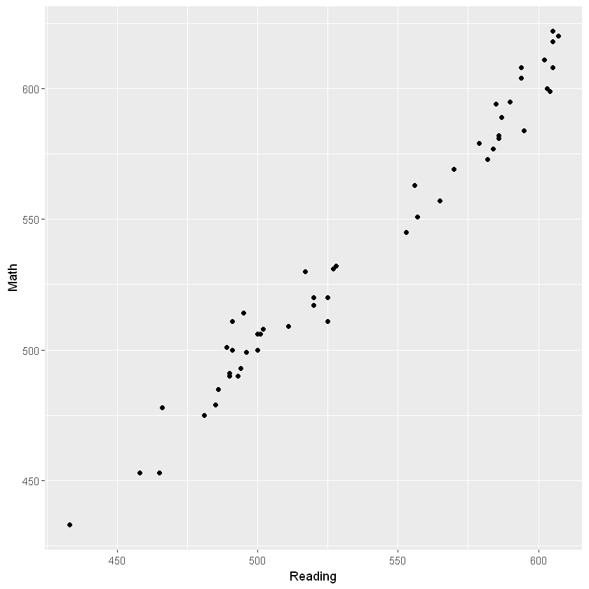

```r
ggplot(SAT, aes(x=Reading, y=Math)) + geom_point()

cor(SAT$Reading, SAT$Math)
```

Puedo predecir la nota en mate si se la de lectura?

Cuidado: Cada punto representa un estado. La correlción no es tan grande.

```r
SAT %>% arrange(desc(Total))
```

| State | Participation | Reading | Math | Writing | Total | New.SAT |
| --- | --- | --- | --- | --- | --- | --- |
| Illinois | 4 | 605 | 622 | 592 | 1819 | 1300 |
| Minnesota | 5 | 607 | 620 | 588 | 1815 | 1300 |
| Wisconsin | 4 | 605 | 618 | 588 | 1811 | 1290 |
| Missouri | 4 | 605 | 608 | 589 | 1802 | 1290 |
| Wyoming | 3 | 603 | 600 | 587 | 1790 | 1280 |
| Kentucky | 4 | 604 | 599 | 586 | 1789 | 1280 |
| Iowa | 3 | 602 | 611 | 572 | 1785 | 1280 |
| Michigan | 4 | 594 | 608 | 581 | 1783 | 1270 |
| Kansas | 5 | 594 | 604 | 571 | 1769 | 1270 |
| Mississippi | 3 | 595 | 584 | 585 | 1764 | 1260 |
| Nebraska | 4 | 590 | 595 | 573 | 1758 | 1260 |
| Colorado | 12 | 587 | 589 | 571 | 1747 | 1250 |
| North Dakota | 2 | 585 | 594 | 560 | 1739 | 1250 |
| Tennessee | 7 | 586 | 582 | 571 | 1739 | 1250 |
| Louisiana | 5 | 584 | 577 | 571 | 1732 | 1240 |
| South Dakota | 3 | 586 | 581 | 558 | 1725 | 1240 |
| Utah | 5 | 579 | 579 | 558 | 1716 | 1230 |
| Oklahoma | 4 | 582 | 573 | 553 | 1708 | 1230 |
| Arkansas | 4 | 570 | 569 | 553 | 1692 | 1210 |
| Montana | 15 | 565 | 557 | 539 | 1661 | 1200 |
| Ohio | 14 | 556 | 563 | 534 | 1653 | 1190 |
| Alabama | 6 | 557 | 551 | 543 | 1651 | 1190 |
| New Mexico | 12 | 553 | 545 | 525 | 1623 | 1170 |
| New Hampshire | 70 | 527 | 531 | 510 | 1568 | 1140 |
| Arizona | 34 | 528 | 532 | 505 | 1565 | 1140 |
| Massachusetts | 86 | 517 | 530 | 506 | 1553 | 1120 |
| Oregon | 47 | 525 | 520 | 500 | 1545 | 1120 |
| Vermont | 61 | 520 | 520 | 501 | 1541 | 1120 |
| West Virginia | 15 | 525 | 511 | 502 | 1538 | 1120 |
| Virginia | 72 | 520 | 517 | 498 | 1535 | 1120 |
| Nevada | 50 | 511 | 509 | 488 | 1508 | 1100 |
| New Jersey | 81 | 495 | 514 | 492 | 1501 | 1090 |
| Connecticut | 89 | 500 | 500 | 497 | 1497 | 1090 |
| Washington | 66 | 501 | 506 | 481 | 1488 | 1090 |
| Pennsylvania | 71 | 500 | 506 | 481 | 1487 | 1090 |
| North Carolina | 63 | 502 | 508 | 475 | 1485 | 1090 |
| Hawaii | 61 | 491 | 511 | 476 | 1478 | 1080 |
| California | 60 | 491 | 500 | 485 | 1476 | 1080 |
| Indiana | 71 | 496 | 499 | 477 | 1472 | 1070 |
| New York | 75 | 489 | 501 | 477 | 1467 | 1070 |
| Rhode Island | 73 | 490 | 491 | 480 | 1461 | 1070 |
| Georgia | 77 | 493 | 490 | 476 | 1459 | 1070 |
| South Carolina | 65 | 494 | 493 | 471 | 1458 | 1060 |
| Maryland | 79 | 490 | 490 | 476 | 1456 | 1070 |
| Maine | 96 | 486 | 485 | 472 | 1443 | 1050 |
| Alaska | 52 | 485 | 479 | 460 | 1424 | 1040 |
| Florida | 74 | 481 | 475 | 462 | 1418 | 1040 |
| Texas | 64 | 466 | 478 | 449 | 1393 | 1020 |
| Idaho | 100 | 465 | 453 | 446 | 1364 | 1000 |
| Delaware | 100 | 458 | 453 | 440 | 1351 | 1000 |
| District of Columbia | 100 | 433 | 433 | 419 | 1285 | 950 |

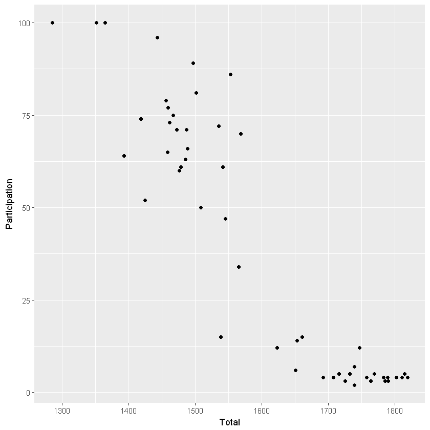

```r
ggplot(SAT, aes(Total, Participation)) + geom_point()
```

```r
SAT # Alabama: pocos estudiantes. Probablemente los mejores tratan de entrar a las U con prestigio.
```

| State | Participation | Reading | Math | Writing | Total | New.SAT |
| --- | --- | --- | --- | --- | --- | --- |
| Alabama | 6 | 557 | 551 | 543 | 1651 | 1190 |
| Alaska | 52 | 485 | 479 | 460 | 1424 | 1040 |
| Arizona | 34 | 528 | 532 | 505 | 1565 | 1140 |
| Arkansas | 4 | 570 | 569 | 553 | 1692 | 1210 |
| California | 60 | 491 | 500 | 485 | 1476 | 1080 |
| Colorado | 12 | 587 | 589 | 571 | 1747 | 1250 |
| Connecticut | 89 | 500 | 500 | 497 | 1497 | 1090 |
| Delaware | 100 | 458 | 453 | 440 | 1351 | 1000 |
| District of Columbia | 100 | 433 | 433 | 419 | 1285 | 950 |
| Florida | 74 | 481 | 475 | 462 | 1418 | 1040 |
| Georgia | 77 | 493 | 490 | 476 | 1459 | 1070 |
| Hawaii | 61 | 491 | 511 | 476 | 1478 | 1080 |
| Idaho | 100 | 465 | 453 | 446 | 1364 | 1000 |
| Illinois | 4 | 605 | 622 | 592 | 1819 | 1300 |
| Indiana | 71 | 496 | 499 | 477 | 1472 | 1070 |
| Iowa | 3 | 602 | 611 | 572 | 1785 | 1280 |
| Kansas | 5 | 594 | 604 | 571 | 1769 | 1270 |
| Kentucky | 4 | 604 | 599 | 586 | 1789 | 1280 |
| Louisiana | 5 | 584 | 577 | 571 | 1732 | 1240 |
| Maine | 96 | 486 | 485 | 472 | 1443 | 1050 |
| Maryland | 79 | 490 | 490 | 476 | 1456 | 1070 |
| Massachusetts | 86 | 517 | 530 | 506 | 1553 | 1120 |
| Michigan | 4 | 594 | 608 | 581 | 1783 | 1270 |
| Minnesota | 5 | 607 | 620 | 588 | 1815 | 1300 |
| Mississippi | 3 | 595 | 584 | 585 | 1764 | 1260 |
| Missouri | 4 | 605 | 608 | 589 | 1802 | 1290 |
| Montana | 15 | 565 | 557 | 539 | 1661 | 1200 |
| Nebraska | 4 | 590 | 595 | 573 | 1758 | 1260 |
| Nevada | 50 | 511 | 509 | 488 | 1508 | 1100 |
| New Hampshire | 70 | 527 | 531 | 510 | 1568 | 1140 |
| New Jersey | 81 | 495 | 514 | 492 | 1501 | 1090 |
| New Mexico | 12 | 553 | 545 | 525 | 1623 | 1170 |
| New York | 75 | 489 | 501 | 477 | 1467 | 1070 |
| North Carolina | 63 | 502 | 508 | 475 | 1485 | 1090 |
| North Dakota | 2 | 585 | 594 | 560 | 1739 | 1250 |
| Ohio | 14 | 556 | 563 | 534 | 1653 | 1190 |
| Oklahoma | 4 | 582 | 573 | 553 | 1708 | 1230 |
| Oregon | 47 | 525 | 520 | 500 | 1545 | 1120 |
| Pennsylvania | 71 | 500 | 506 | 481 | 1487 | 1090 |
| Rhode Island | 73 | 490 | 491 | 480 | 1461 | 1070 |
| South Carolina | 65 | 494 | 493 | 471 | 1458 | 1060 |
| South Dakota | 3 | 586 | 581 | 558 | 1725 | 1240 |
| Tennessee | 7 | 586 | 582 | 571 | 1739 | 1250 |
| Texas | 64 | 466 | 478 | 449 | 1393 | 1020 |
| Utah | 5 | 579 | 579 | 558 | 1716 | 1230 |
| Vermont | 61 | 520 | 520 | 501 | 1541 | 1120 |
| Virginia | 72 | 520 | 517 | 498 | 1535 | 1120 |
| Washington | 66 | 501 | 506 | 481 | 1488 | 1090 |
| West Virginia | 15 | 525 | 511 | 502 | 1538 | 1120 |
| Wisconsin | 4 | 605 | 618 | 588 | 1811 | 1290 |
| Wyoming | 3 | 603 | 600 | 587 | 1790 | 1280 |

Cuidado con agragaciones, no linearidad, outliers.